# Class 17: COVID-19 Vaccination Rate Mini Project

Barry (PID: 911)

11/23/2021

# Background

As we approach a period of travel and larger gatherings lets have a look at vaccination rates across the State.

We will take data from the CA.gov site here: - “Statewide COVID-19 Vaccines Administered by ZIP Code” https://data.ca.gov/dataset/covid-19-vaccine-progress-dashboard-data-by-zip-code

```r
vax <- read.csv("covid19vaccinesbyzipcode.csv")
head(vax)
```

```
##   as_of_date zip_code_tabulation_area local_health_jurisdiction    county
## 1 2021-01-05                    92804                    Orange    Orange
## 2 2021-01-05                    92626                    Orange    Orange
## 3 2021-01-05                    92250                  Imperial  Imperial
## 4 2021-01-05                    92637                    Orange    Orange
## 5 2021-01-05                    92155                 San Diego San Diego
## 6 2021-01-05                    92259                  Imperial  Imperial
##   vaccine_equity_metric_quartile                 vem_source
## 1                              2 Healthy Places Index Score
## 2                              3 Healthy Places Index Score
## 3                              1 Healthy Places Index Score
## 4                              3 Healthy Places Index Score
## 5                             NA            No VEM Assigned
## 6                              1    CDPH-Derived ZCTA Score
##   age12_plus_population age5_plus_population persons_fully_vaccinated
```

[output cut: 34 more lines]

## Quick look at data structure

As before we can use the **skim()** function to quickly overview and summarize the various columns of the dataset.

```r
skimr::skim(vax)
```

Data summary

| Name | vax |
| --- | --- |
| Number of rows | 81144 |
| Number of columns | 14 |
| _______________________ |  |
| Column type frequency: |  |
| character | 5 |
| numeric | 9 |
| ________________________ |  |
| Group variables | None |

**Variable type: character**

| skim_variable | n_missing | complete_rate | min | max | empty | n_unique | whitespace |
| --- | --- | --- | --- | --- | --- | --- | --- |
| as_of_date | 0 | 1 | 10 | 10 | 0 | 46 | 0 |
| local_health_jurisdiction | 0 | 1 | 0 | 15 | 230 | 62 | 0 |
| county | 0 | 1 | 0 | 15 | 230 | 59 | 0 |
| vem_source | 0 | 1 | 15 | 26 | 0 | 3 | 0 |
| redacted | 0 | 1 | 2 | 69 | 0 | 2 | 0 |

**Variable type: numeric**

| skim_variable | n_missing | complete_rate | mean | sd | p0 | p25 | p50 | p75 | p100 | hist |
| --- | --- | --- | --- | --- | --- | --- | --- | --- | --- | --- |
| zip_code_tabulation_area | 0 | 1.00 | 93665.11 | 1817.39 | 90001 | 92257.75 | 93658.50 | 95380.50 | 97635.0 | ▃▅▅▇▁ |
| vaccine_equity_metric_quartile | 4002 | 0.95 | 2.44 | 1.11 | 1 | 1.00 | 2.00 | 3.00 | 4.0 | ▇▇▁▇▇ |
| age12_plus_population | 0 | 1.00 | 18895.04 | 18993.94 | 0 | 1346.95 | 13685.10 | 31756.12 | 88556.7 | ▇▃▂▁▁ |
| age5_plus_population | 0 | 1.00 | 20875.24 | 21106.05 | 0 | 1460.50 | 15364.00 | 34877.00 | 101902.0 | ▇▃▂▁▁ |
| persons_fully_vaccinated | 8256 | 0.90 | 9456.49 | 11498.25 | 11 | 506.00 | 4105.00 | 15859.00 | 71078.0 | ▇▂▁▁▁ |
| persons_partially_vaccinated | 8256 | 0.90 | 1900.61 | 2113.07 | 11 | 200.00 | 1271.00 | 2893.00 | 20185.0 | ▇▁▁▁▁ |
| percent_of_population_fully_vaccinated | 8256 | 0.90 | 0.42 | 0.27 | 0 | 0.19 | 0.44 | 0.62 | 1.0 | ▇▆▇▆▂ |
| percent_of_population_partially_vaccinated | 8256 | 0.90 | 0.10 | 0.10 | 0 | 0.06 | 0.07 | 0.11 | 1.0 | ▇▁▁▁▁ |
| percent_of_population_with_1_plus_dose | 8256 | 0.90 | 0.50 | 0.26 | 0 | 0.30 | 0.53 | 0.70 | 1.0 | ▅▅▇▇▃ |

## Ensure the date column is useful

We will use the **lubridate** package to make life allot easier when dealing with dates and times:

```r
library(lubridate)
today()
```

```
## [1] "2021-11-23"
```

Here we make our `as_of_date` column lubridate format…

```r
# Specify that we are using the Year-mont-day format
vax$as_of_date <- ymd(vax$as_of_date)
```

Now I can do useful math with dates more easily:

> 17. How many days since the first entry?

```r
today() - vax$as_of_date[1]
```

```
## Time difference of 322 days
```

> Q. How many days since the last entry?

```r
today() - vax$as_of_date[ nrow(vax) ]
```

```
## Time difference of 7 days
```

> Q9. **How many days between the first and last entry in the dataset?**

```r
vax$as_of_date[ nrow(vax)] - vax$as_of_date[1]
```

```
## Time difference of 315 days
```

> Q10. How many unique dates are in the dataset (i.e. how many different dates are detailed)?

```r
length( unique(vax$as_of_date) )
```

```
## [1] 46
```

This sounds good

```r
46*7
```

```
## [1] 322
```

## Working with ZIP codes

We will use the **zipcodeR** package to help make sense of zip codes. For example:

```r
library(zipcodeR)

geocode_zip('92037')
```

```
## # A tibble: 1 × 3
##   zipcode   lat   lng
##   <chr>   <dbl> <dbl>
## 1 92037    32.8 -117.
```

More usefully, we can pull census data about ZIP code areas (including median household income etc.). For example:

```r
reverse_zipcode(c('92037', "92109") )
```

```
## # A tibble: 2 × 24
##   zipcode zipcode_type major_city post_office_city common_city_list county state
##   <chr>   <chr>        <chr>      <chr>                      <blob> <chr>  <chr>
## 1 92037   Standard     La Jolla   La Jolla, CA           <raw 20 B> San D… CA
## 2 92109   Standard     San Diego  San Diego, CA          <raw 21 B> San D… CA
## # … with 17 more variables: lat <dbl>, lng <dbl>, timezone <chr>,
## #   radius_in_miles <dbl>, area_code_list <blob>, population <int>,
## #   population_density <dbl>, land_area_in_sqmi <dbl>,
## #   water_area_in_sqmi <dbl>, housing_units <int>,
## #   occupied_housing_units <int>, median_home_value <int>,
## #   median_household_income <int>, bounds_west <dbl>, bounds_east <dbl>,
## #   bounds_north <dbl>, bounds_south <dbl>
```

# Focus on San Diego County

```r
table(vax$county)
```

```
##
##                         Alameda          Alpine          Amador           Butte
##             230            2254              46             552             828
##       Calaveras          Colusa    Contra Costa       Del Norte       El Dorado
##             828             322            1978             184            1012
##          Fresno           Glenn        Humboldt        Imperial            Inyo
##            2530             276            1610             690             460
##            Kern           Kings            Lake          Lassen     Los Angeles
##            2254             322             644             598           13340
##          Madera           Marin        Mariposa       Mendocino          Merced
##             552            1288             368            1196             874
##           Modoc            Mono        Monterey            Napa          Nevada
##             506             322            1288             460             552
##          Orange          Placer          Plumas       Riverside      Sacramento
##            4048            1334             736            3220            2484
##      San Benito  San Bernardino       San Diego   San Francisco     San Joaquin
##             184            4094            4922            1242            1472
## San Luis Obispo       San Mateo   Santa Barbara     Santa Clara      Santa Cruz
##            1012            1334            1058            2668             782
##          Shasta          Sierra        Siskiyou          Solano          Sonoma
##            1196             322             966             690            1656
##      Stanislaus          Sutter          Tehama         Trinity          Tulare
##            1104             414             598             598            1518
##        Tuolumne         Ventura            Yolo            Yuba
##             598            1242             782             506
```

We can subset with base R

```r
inds <- vax$county == "San Diego"

head(vax[inds,])
```

```
##    as_of_date zip_code_tabulation_area local_health_jurisdiction    county
## 5  2021-01-05                    92155                 San Diego San Diego
## 14 2021-01-05                    92147                 San Diego San Diego
## 16 2021-01-05                    92124                 San Diego San Diego
## 24 2021-01-05                    92145                 San Diego San Diego
## 34 2021-01-05                    91935                 San Diego San Diego
## 36 2021-01-05                    92102                 San Diego San Diego
##    vaccine_equity_metric_quartile                 vem_source
## 5                              NA            No VEM Assigned
## 14                             NA            No VEM Assigned
## 16                              3 Healthy Places Index Score
## 24                             NA            No VEM Assigned
## 34                              3 Healthy Places Index Score
## 36                              1 Healthy Places Index Score
##    age12_plus_population age5_plus_population persons_fully_vaccinated
```

[output cut: 34 more lines]

But let’s use the **dplyr** package and it’s **filter()** function:

```r
library(dplyr)
sd <- filter(vax, county=="San Diego")
head(sd)
```

```
##   as_of_date zip_code_tabulation_area local_health_jurisdiction    county
## 1 2021-01-05                    92155                 San Diego San Diego
## 2 2021-01-05                    92147                 San Diego San Diego
## 3 2021-01-05                    92124                 San Diego San Diego
## 4 2021-01-05                    92145                 San Diego San Diego
## 5 2021-01-05                    91935                 San Diego San Diego
## 6 2021-01-05                    92102                 San Diego San Diego
##   vaccine_equity_metric_quartile                 vem_source
## 1                             NA            No VEM Assigned
## 2                             NA            No VEM Assigned
## 3                              3 Healthy Places Index Score
## 4                             NA            No VEM Assigned
## 5                              3 Healthy Places Index Score
## 6                              1 Healthy Places Index Score
##   age12_plus_population age5_plus_population persons_fully_vaccinated
```

[output cut: 34 more lines]

How many entries are there for San Diego county?

```r
nrow(sd)
```

```
## [1] 4922
```

> Q11. How many distinct zip codes are listed for San Diego County?

```r
length( unique(sd$zip_code_tabulation_area) )
```

```
## [1] 107
```

> Q12. What San Diego County Zip code area has the largest 12 + Population in this dataset?

```r
ind <- which.max(sd$age12_plus_population)
sd[ind,]
```

```
##    as_of_date zip_code_tabulation_area local_health_jurisdiction    county
## 23 2021-01-05                    92154                 San Diego San Diego
##    vaccine_equity_metric_quartile                 vem_source
## 23                              2 Healthy Places Index Score
##    age12_plus_population age5_plus_population persons_fully_vaccinated
## 23               76365.2                82971                       32
##    persons_partially_vaccinated percent_of_population_fully_vaccinated
## 23                         1336                               0.000386
##    percent_of_population_partially_vaccinated
## 23                                   0.016102
##    percent_of_population_with_1_plus_dose redacted
## 23                               0.016488       No
```

> Q. **What is the population in the 92037 ZIP code area?**

```r
filter(sd, zip_code_tabulation_area == "92037")[1,]
```

```
##   as_of_date zip_code_tabulation_area local_health_jurisdiction    county
## 1 2021-01-05                    92037                 San Diego San Diego
##   vaccine_equity_metric_quartile                 vem_source
## 1                              4 Healthy Places Index Score
##   age12_plus_population age5_plus_population persons_fully_vaccinated
## 1               33675.6                36144                       44
##   persons_partially_vaccinated percent_of_population_fully_vaccinated
## 1                         1265                               0.001217
##   percent_of_population_partially_vaccinated
## 1                                   0.034999
##   percent_of_population_with_1_plus_dose redacted
## 1                               0.036216       No
```

> Q13. What is the overall average “Percent of Population Fully Vaccinated” value for all San Diego “County” as of “2021-11-09”?

```r
sd.now <- filter(sd, as_of_date=="2021-11-09")

mean(sd.now$percent_of_population_fully_vaccinated, na.rm=TRUE)
```

```
## [1] 0.6727567
```

We can look at the 6-number summary

```r
summary( sd.now$percent_of_population_fully_vaccinated )
```

```
##    Min. 1st Qu.  Median    Mean 3rd Qu.    Max.    NA's
## 0.01017 0.60776 0.67700 0.67276 0.76164 1.00000       4
```

> Q14. Using either ggplot or base R graphics make a summary figure that shows the distribution of Percent of Population Fully Vaccinated values as of “2021-11-09”?

Using base R plots

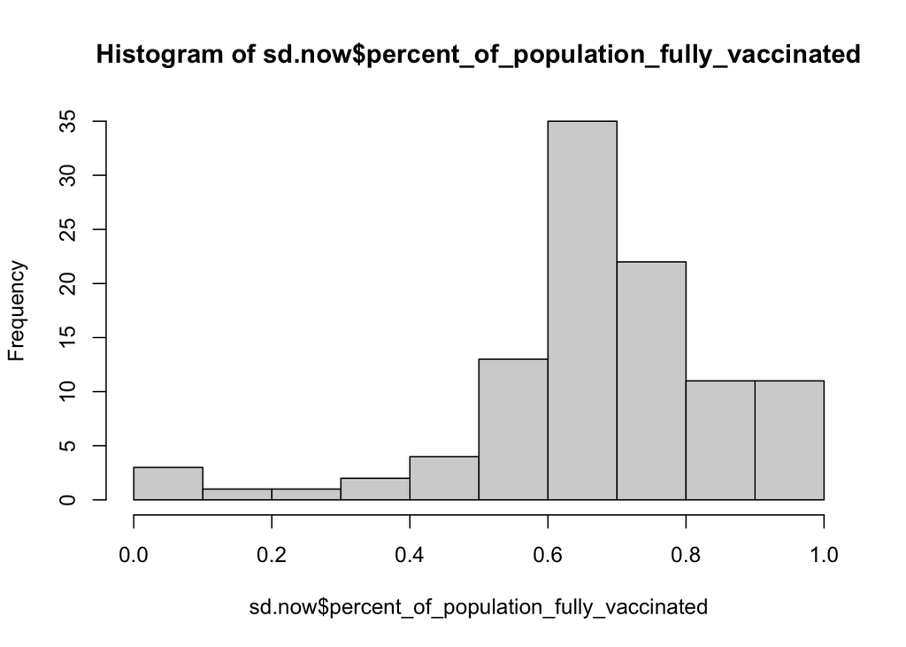

```r
hist( sd.now$percent_of_population_fully_vaccinated )
```

Using ggplot

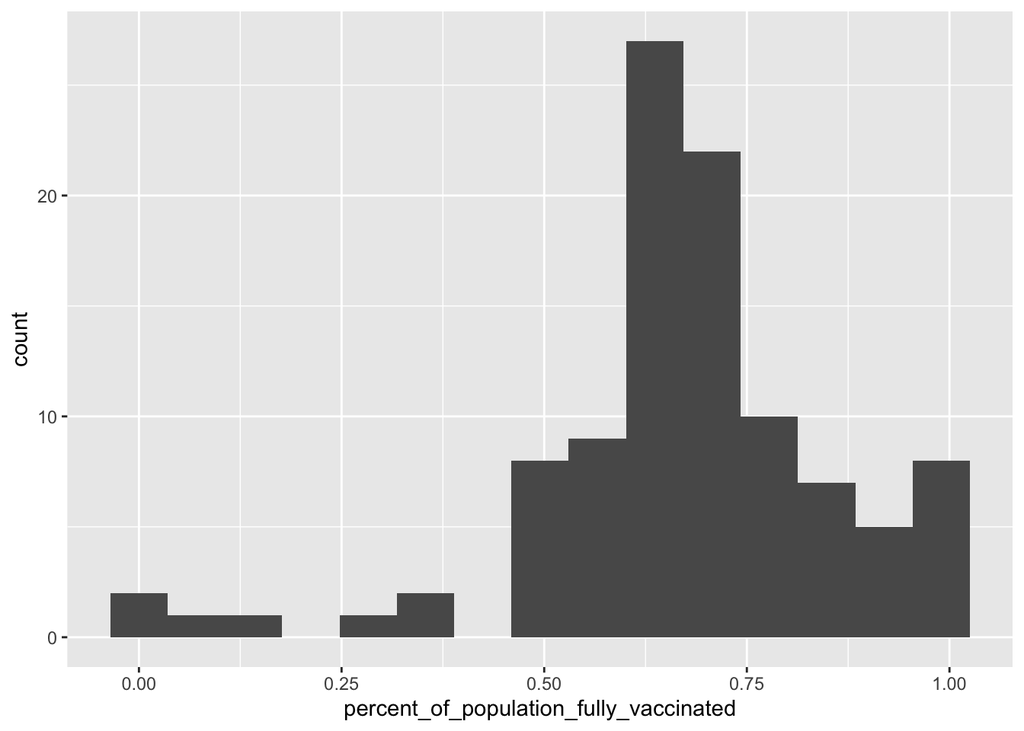

```r
library(ggplot2)

ggplot(sd.now) +
  aes(percent_of_population_fully_vaccinated) +
  geom_histogram(bins=15)
```

What about 92037 - UCSD/ La Jolla?

```r
filter(sd.now, zip_code_tabulation_area == "92037")
```

```
##   as_of_date zip_code_tabulation_area local_health_jurisdiction    county
## 1 2021-11-09                    92037                 San Diego San Diego
##   vaccine_equity_metric_quartile                 vem_source
## 1                              4 Healthy Places Index Score
##   age12_plus_population age5_plus_population persons_fully_vaccinated
## 1               33675.6                36144                    32859
##   persons_partially_vaccinated percent_of_population_fully_vaccinated
## 1                         6354                               0.909114
##   percent_of_population_partially_vaccinated
## 1                                   0.175797
##   percent_of_population_with_1_plus_dose redacted
## 1                                      1       No
```

## Time series of vaccination rate for 92037

First select all data for the UCSD 92037 area

```r
ucsd <- filter(vax, zip_code_tabulation_area == "92037")
```

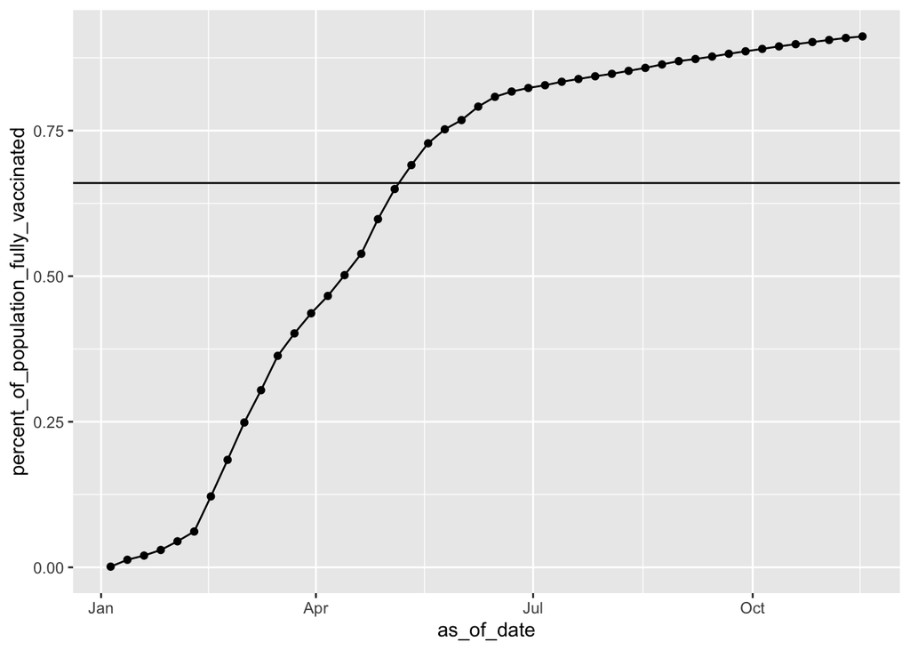

```r
ggplot(ucsd) +
  aes(as_of_date, percent_of_population_fully_vaccinated) +
  geom_point() +
  geom_line(group=1) +
  geom_hline(yintercept = 0.66)
```

Population in the 92037 ZIP code area

```r
ucsd[1,]$age5_plus_population
```

```
## [1] 36144
```

First we need to subset the full `vax` dataset to include only ZIP code areas with a population as large as 92037

```r
vax.36.all <- filter(vax, age5_plus_population > 36144)
nrow(vax.36.all)
```

```
## [1] 18906
```

How many unique zip codes have a population as large as 92037?

```r
length(unique( vax.36.all$zip_code_tabulation_area ))
```

```
## [1] 411
```

Lets make a final figure that shows all these ZIP areas.

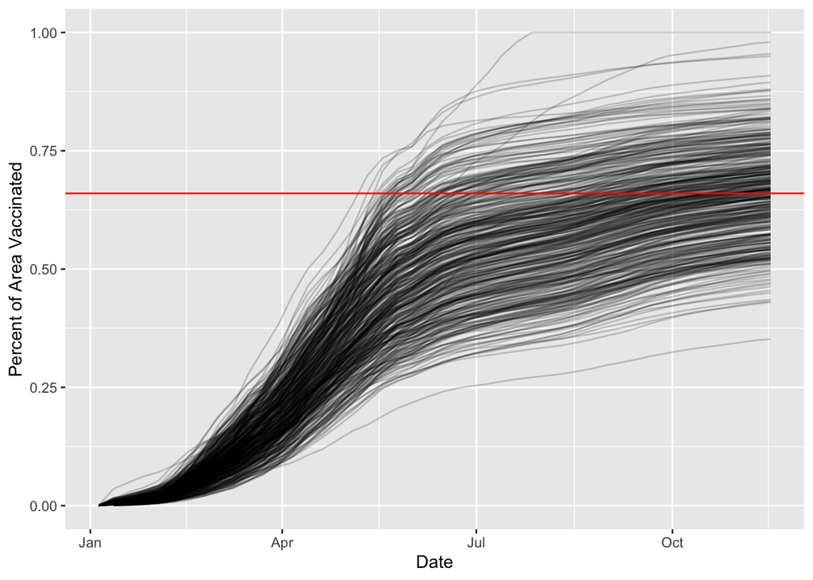

```r
ggplot(vax.36.all) +
  aes(as_of_date,
      percent_of_population_fully_vaccinated,
      group=zip_code_tabulation_area) +
  geom_line( alpha=0.2 ) +
  geom_hline(yintercept = 0.66, col="red") +
  labs(x="Date", y="Percent of Area Vaccinated")
```